# Intro to RMarkdown

Leigh Phan

4/23/2020

**To create an R Markdown document in RStudio, select `File` > `New File` > `R Markdown`.

### Headers

In Markdown, create headers using a hierachy, from H1, represented by `#` to H6, represented by `######`.

### Text

It’s very easy to make some words **bold** and other words *italic* with Markdown.

### Adding Code to Your R Markdown File

- Remember that you can use the keyboard shortcut **Ctrl + Alt + I** (*OS X*: **Cmd + Option + I**)

## Exporting Rmarkdown

In order to export in RStudio, select the **Knit** button in the upper-left corner; in the drop-down, select a format and location to save the file. R Markdown files can be exported to a wide range of document types, including HTML, PDF, and MS Word.

Now you have the tools to create and produce a report including your text, data, code, figures, and more! We’ll cover creating reports in more detail in our next workshop on May 1, 2020.

Until then, enjoy exploring and creating with Markdown!

*The following are supplemental guides*:

- [RStudio Guide to Markdown](https://github.com/rstudio/cheatsheets/blob/master/rmarkdown-2.0.pdf) (Right-click the image to view larger version, or download a copy)
- [GitHub Guide to Mastering Markdown](https://guides.github.com/features/mastering-markdown/)

## Creating Plots Using ggplot2

**ggplot2** is a library used in R to creative graphics and charts. The library is based on concepts of [The Grammar of Graphics by Leland Wilkinson](https://link.springer.com/book/10.1007%2F978-1-4757-3100-2), the idea that you can build every graph from same components:

- a **data** set
- a **coordinate system**
- **geoms** – visual marks that represent data points (short for “geometries”)

(“Grammar of Graphics” - hence the “GG” in “ggplot2”!)

#### Let’s get started with ggplot2 by loading the R Library, `ggplot2`:

```r
library(gapminder)
library(ggplot2)
```

- country
- continent
- year
- lifeExp (life expectancy)
- pop
- gdpPercap (Gross Domestic product)

This is important to remember, so that when we begin creating graphics, we’ll reference these in our code.

Example: let’s say, using gapminder data, we want to create a graph displaying the life expectancy of each country in relation to GDP per capita.

## Layers

- Using a scatterplot probably isn’t the best for visualizing change over time. Instead, let’s tell ggplot to visualize the data as a line plot.

- To our current chart, we’ll add another aesthetic, called `**by**` and set it to one of the data variables, `country`
- From our previous challenge, let’s continue to differentiate each continent by color
- What do you think we need to change in our code in order to create a line graph (instead of a scatterplot)?
- `by` aesthetic tells `ggplot` to draw a line for each country

What if we want to visualize both **lines** and **points** on the plot?

#### Challenge Set 2

1. Switch the order of the point and line layers from the previous example. What happened?

### Setting an aesthetic to a value instead of mapping

So far we’ve seen how to use an aes (such as color) as a mapping to a variable in the data.

```r
# geom_line(mapping = aes(color=continent))
```

But what if we want to change the color of all lines to blue?

```r
# geom_line(mapping=aes(color="blue"))
```

Since we don’t want to create a mapping to a specific variable, we move the color specification outside of the `aes()` function. e.g.:

```r
# geom_line(color="blue")
```

## Transformations & Statistics

```r
# ggplot(data = gapminder, mapping = aes(x = gdpPercap, y = lifeExp)) + geom_point()
```

### Challenge Set 3

1. Modify the color and size of the points on the point layer in the previous example. Hint: do not use the `aes` function.
2. Modify your solution to the previous challenge so that the points are now a different shape and are colored by continent with new trendlines. Hint: The color argument can be used inside the aesthetic.

## Multi-panel figures

We start by making a subset of data including only countries located in the Americas. This includes 25 countries, which will begin to clutter the figure. Note that we apply a “theme” definition to rotate the x-axis labels to maintain readability. Nearly everything in ggplot2 is customizable.

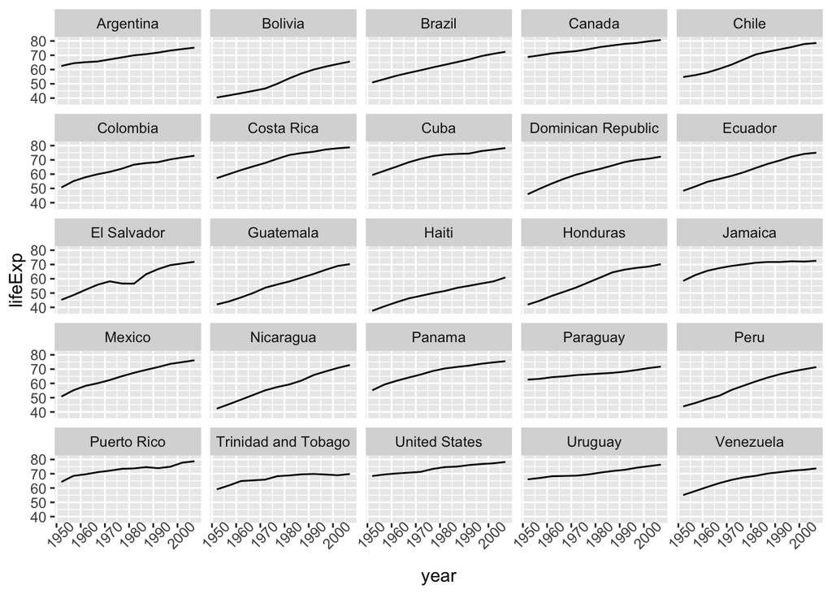

```r
americas <- gapminder[gapminder$continent == "Americas",]
ggplot(data = americas, mapping = aes(x = year, y = lifeExp)) +
  geom_line() +
  facet_wrap( ~ country) +
  theme(axis.text.x = element_text(angle = 45))
```

## Modifying text

To clean this figure up for publication, we need to change some text elements.

We can do this by adding some different layers.

- **theme** layer - controls the axis text and overall text size.
- **labs** function - Sets the labels for axes, plot title, and any legend
- **aes** - Legend titles are set using same names used in `aes`
- Below the color legend title is set using `color = "Continent"`, while the title of a fill legend would be set using `fill = "MyTitle"`.

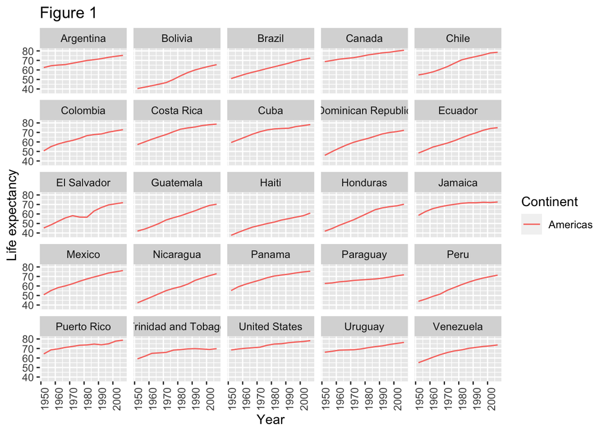

```r
ggplot(data = americas, mapping = aes(x = year, y = lifeExp, color=continent)) +
  geom_line() + facet_wrap( ~ country) +
  labs(
    x = "Year",              # x axis title
    y = "Life expectancy",   # y axis title
    title = "Figure 1",      # main title of figure
    color = "Continent"      # title of legend
  ) +
  theme(axis.text.x = element_text(angle = 90, hjust = 1))
```

## Exporting the plot

Export a plot using `**ggsave()**` -

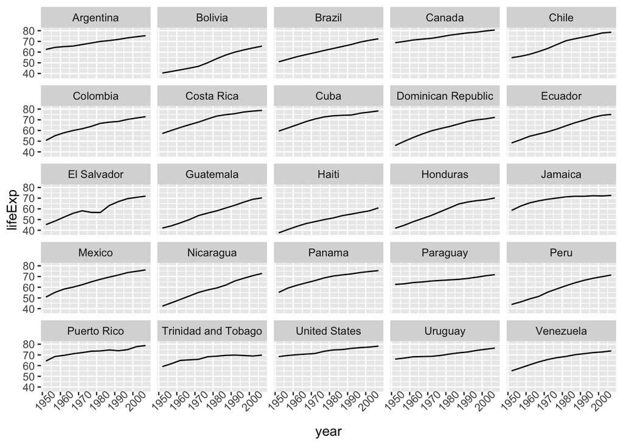

```r
americas <- gapminder[gapminder$continent == "Americas",]
ggplot(data = americas, mapping = aes(x = year, y = lifeExp)) +
  geom_line() +
  facet_wrap( ~ country) +
  theme(axis.text.x = element_text(angle = 45))
```

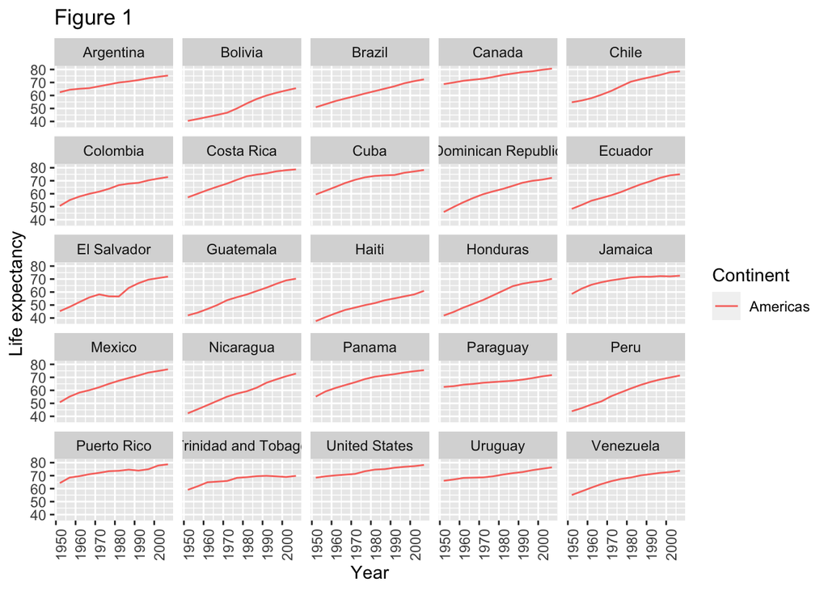

```r
ggplot(data = americas, mapping = aes(x = year, y = lifeExp, color=continent)) +
  geom_line() + facet_wrap( ~ country) +
  labs(
    x = "Year",              # x axis title
    y = "Life expectancy",   # y axis title
    title = "Figure 1",      # main title of figure
    color = "Continent"      # title of legend
  ) +
  theme(axis.text.x = element_text(angle = 90, hjust = 1))
```

```r
lifeExp_plot <- ggplot(data = americas, mapping = aes(x = year, y = lifeExp, color=continent)) +
  geom_line() + facet_wrap( ~ country) +
  labs(
    x = "Year",              # x axis title
    y = "Life expectancy",   # y axis title
    title = "Figure 1",      # main title of figure
    color = "Continent"      # title of legend
  ) +
  theme(axis.text.x = element_text(angle = 90, hjust = 1))

ggsave(filename = "results/lifeExp.png", plot = lifeExp_plot, width = 12, height = 10, dpi = 300, units = "cm")
```

```r
packageVersion("ggplot2")
```

```
## [1] '3.3.0'
```

#### Challenge Set 4

Generate boxplots to compare life expectancy between the different continents during the available years.

Advanced: * Rename y axis as Life Expectancy. * Remove x axis labels.